# Impact of COVID-19 Related Transition to Online Instruction on Student Achievement

Jason Holderieath

8/8/2020

For research purposes, this situation provides a natural experiment. Most courses of instruction were interrupted mid-term. LaTech transitioned online over a weekend that followed “syllabus day.” This provides an opportunity to examine the impacts of a sudden shift in the mode of instruction, without the weight of weeks of traditional course delivery.

# Methods

The authors requested grade information from the Registrar’s office. We were unable to acquire any demographic data to accompany the grades, nor were we successful in gaining permission to use our own records from the Human Use Committee. This is a severely incomplete picture of the determinants of grade; however, it is all we have.

The Registrar’s office grade report contains information on instructor, course, term, and grade awarded for three spring terms (2018, 2019, and 2020) of courses offered through the School of Agricultural Sciences and Forestry (SASF). This results in a dataset with 2205 observations. Grades are the traditional “A-F” sequence with “W” for withdrawal. The University extended the “W” (Withdrawal) deadline for Spring 2020 from May 1, 2020, to May 15, 2020 and also provided an opportunity for students to choose “PASS/FAIL” grading not previously available at LaTech. Students were able to elect “PASS/FAIL” *after* the term was complete (“Interim Emergency Policy for Academics Spring Quarter 2020, COVID-19” 2020).

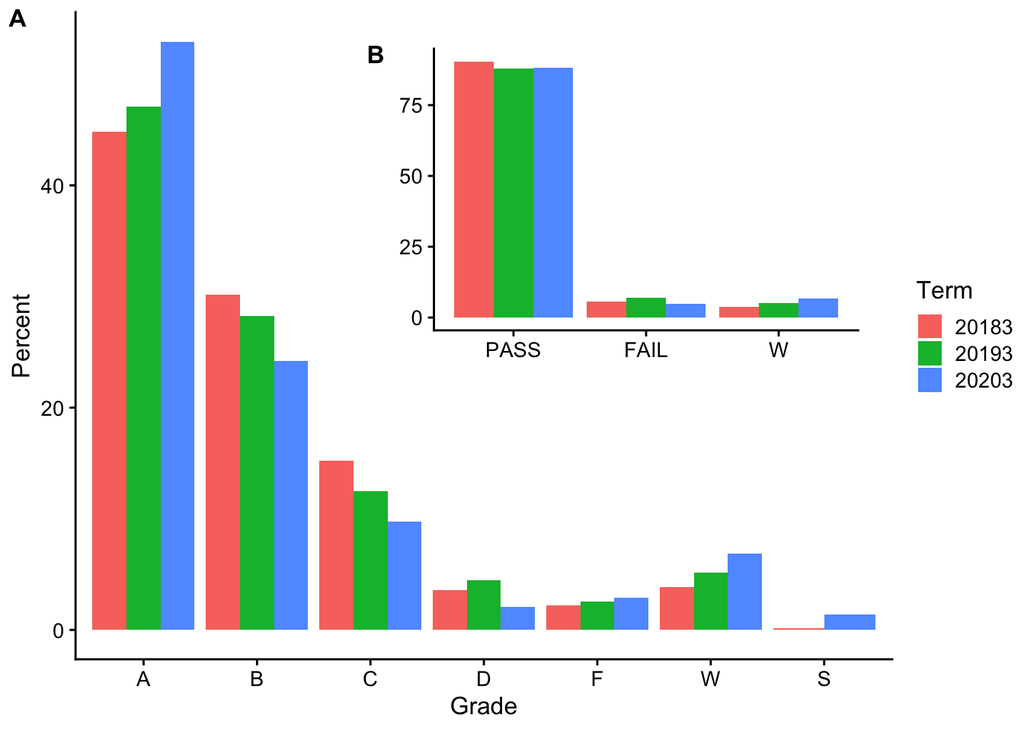

The nature of the grades requires a two step estimation process. A typical two step estimator might take the form of a binary dependent followed by a poisson dependent variable, such as applied to some global trade models. However, due to “W” not fitting in the order between “A-F” and the new “PASS/FAIL” option, the first step estimator is a multinomial logistic regression where the dependent variable takes the form of “W,” “PASS,” and “FAIL.” The second stage could be estimated as a ordinal logistic regression, so long as the proportional odds assumption is met. The proportional odds assumption means that predictors, in our case only instructor and term, have the same odds of moving the observation to a higher-order category.

# References

University Registrar. 2020. “Spring Quarter 2020.” https://boss.latech.edu/.

“Update for Students | Louisiana Tech University.” 2020. https://www.latech.edu/coronavirus/messages/update-for-students/.